# Entrega 1 - Pre-Procesamiento

Minería de Datos

Andrés Campos Cuiña

22/02/2022

# Introducción

Definimos el directorio de trabajo:

```r
setwd("c:/Users/Andres/Google Drive/USC/MaBD/Mineria de Datos/Practicas/Practica1/")
```

# Valores Especiales

## Ejercicio 1:

### Ejercicio 1.1

```r
NA + 1
```

```
## [1] NA
```

El resultado es `NA` ya que la suma de un valor a un dato desconocido sigue siendo desconocido.

### Ejercicio 1.2

```r
sum(c(NA,1,2))
```

```
## [1] NA
```

Igual que en el ejercicio anterior, el resultado es `NA` ya que la suma de un valor a un dato desconocido sigue siendo desconocido.

### Ejercicio 1.3

```r
median(c(NA,1,2,3), na.rm = TRUE)
```

```
## [1] 2
```

La opción `na.rm=TRUE` elimina los valores `NA` por lo que la mediana se calcula de forma normal con los otros 3 valores presentes en el vector.

### Ejercicio 1.4

```r
length(c(NA,2,3,4))
```

```
## [1] 4
```

El valor `NA`, pese a ser un valor que no está disponible sí que se cuenta como uno de los valores presentes en el vector.

### Ejercicio 1.5

```r
3 == NA
```

```
## [1] NA
```

Como el valor de `NA` no está disponible, el resultado de compararlo con otro valor real tampoco será un valor que podamos conocer.

### Ejercicio 1.6

```r
sum(c(2,3,NULL,4))
```

```
## [1] 9
```

El valor `NULL` se puede considerar como el conjunto vacío, por lo que no se tiene en cuenta para hacer la suma de los elementos del vector.

### Ejercicio 1.7

```r
x <- NULL
```

Se le asigna a `x` el valor `NULL`.

### Ejercicio 1.8

```r
NaN == NULL
```

```
## logical(0)
```

La respuesta `logical(0)` nos indica que tenemos un vector que debería contener valores booleanos pero que está vacío. Este se debe a que los valores NaN y NULL no se pueden comparar.

### Ejercicio 1.9

```r
NULL == NULL
```

```
## logical(0)
```

Al igual que en el ejercicio anterior, dos valores `NULL` no son comparables.

### Ejercicio 1.10

```r
c <- 2
```

Se le asigna a `c` el valor 2.

### Ejercicio 1.11

```r
pi/0
```

```
## [1] Inf
```

R utiliza el estándar [IEE754](https://stat.ethz.ch/R-manual/R-devel/library/base/html/double.html) según el cual la división entre 0 es infinito. Sin embargo, matemáticamente la división entre 0 es un valor indefinido.

### Ejercicio 1.12

```r
2*Inf
```

```
## [1] Inf
```

El doble de infinito sigue siendo infinito.

### Ejercicio 1.13

```r
Inf - 10e+10
```

```
## [1] Inf
```

Infinito menos cualquier otro valor que no sea infinito sigue siendo infinito.

### Ejercicio 1.14

```r
Inf+Inf
```

```
## [1] Inf
```

Igual que en el caso de 2*`Inf`, el doble de infinito sigue siendo infinito.

### Ejercicio 1.15

```r
exp(-Inf)
```

```
## [1] 0
```

El valor de $e^x$ cuando $x$ se acerca a menos infinito tiende a 0.

### Ejercicio 1.16

```r
3 < -Inf
```

```
## [1] FALSE
```

Ningún valor puede ser menor que menos infinito, por eso esta comparación nos devuelve el valor booleano `FALSE`.

### Ejercicio 1.17

```r
exp(NaN)
```

```
## [1] NaN
```

Las operaciones que implican un `NaN` devuelven un `NaN`.

# Lectura de Datos

## Ejercicio 2

### Ejercicio 2.1

Creo que la primera columna debe de tener el tipo de dato `integer`, de la segunda a la duodécima columna el tipo de dato `factor` (debido a que parece que indican la presencia o falta de alguna característica), la decimotercera columna un valor de tipo `numeric`, la decimocuarta de tipo `integer`, la decimoquinta de tipo `integer` también, la decimosexta de tipo `numeric`, la decimoséptima `numeric` también, la decimoctava de tipo `factor` y la última columna de tipo `factor`.

### Ejercicio 2.2

Sí, están representados mediante un ’*’.

### Ejercicio 2.3

Creo que falta información sobre ciertas de las características para algunas de las muestras de nuestro dataset. Sin nombres para las columnas, es complicado poderle dar más sentido a estos datos.

## Ejercicio 3

Importamos los datos mediante el uso de la función `read.csv` sin modificar los parámetros.

```r
hepatitis = read.csv('./data/hepatitis.csv')
```

### Ejercicio 3.1

Ejecutamos el comando `str(hepatitis)`:

```r
str(hepatitis)
```

```
## 'data.frame':    154 obs. of  20 variables:
##  $ X30  : int  50 78 31 34 34 51 23 39 30 39 ...
##  $ X1   : int  0 0 0 0 0 0 0 0 0 0 ...
##  $ X0   : chr  "0" "1" "*" "1" ...
##  $ X0.1 : int  0 0 1 0 0 0 0 0 0 1 ...
##  $ X0.2 : chr  "1" "1" "0" "0" ...
##  $ X0.3 : chr  "0" "0" "0" "0" ...
##  $ X0.4 : chr  "0" "0" "0" "0" ...
##  $ X0.5 : chr  "0" "1" "1" "1" ...
##  $ X0.6 : chr  "0" "0" "0" "0" ...
##  $ X0.7 : chr  "0" "0" "0" "0" ...
##  $ X0.8 : chr  "0" "0" "0" "0" ...
##  $ X0.9 : chr  "0" "0" "0" "0" ...
##  $ X0.10: chr  "0" "0" "0" "0" ...
##  $ X1.0 : chr  "0.9" "0.7" "0.7" "1.0" ...
##  $ X85  : chr  "135" "96" "46" "*" ...
##  $ X18  : chr  "42" "32" "52" "200" ...
##  $ X4.0 : chr  "3.5" "4.0" "4.0" "4.0" ...
##  $ X.   : chr  "*" "*" "80" "*" ...
##  $ X0.11: int  0 0 0 0 0 0 0 0 0 0 ...
##  $ X1.1 : int  1 1 1 1 1 0 1 1 1 1 ...
```

Encontramos las siguientes anomalías: - Se ha leído la primera fila como si fuese el `header`. - Muchas de las columnas toman valores del tipo `char` cuando deberían ser del tipo `integer` o `factor`. - Los valores que faltan aparecen como `*` en lugar de como valores vacíos.

A continuación ejecutamos la función `complete.cases(hepatitis)`:

```r
complete.cases(hepatitis)
```

```
##   [1] TRUE TRUE TRUE TRUE TRUE TRUE TRUE TRUE TRUE TRUE TRUE TRUE TRUE TRUE TRUE
##  [16] TRUE TRUE TRUE TRUE TRUE TRUE TRUE TRUE TRUE TRUE TRUE TRUE TRUE TRUE TRUE
##  [31] TRUE TRUE TRUE TRUE TRUE TRUE TRUE TRUE TRUE TRUE TRUE TRUE TRUE TRUE TRUE
##  [46] TRUE TRUE TRUE TRUE TRUE TRUE TRUE TRUE TRUE TRUE TRUE TRUE TRUE TRUE TRUE
##  [61] TRUE TRUE TRUE TRUE TRUE TRUE TRUE TRUE TRUE TRUE TRUE TRUE TRUE TRUE TRUE
##  [76] TRUE TRUE TRUE TRUE TRUE TRUE TRUE TRUE TRUE TRUE TRUE TRUE TRUE TRUE TRUE
##  [91] TRUE TRUE TRUE TRUE TRUE TRUE TRUE TRUE TRUE TRUE TRUE TRUE TRUE TRUE TRUE
## [106] TRUE TRUE TRUE TRUE TRUE TRUE TRUE TRUE TRUE TRUE TRUE TRUE TRUE TRUE TRUE
## [121] TRUE TRUE TRUE TRUE TRUE TRUE TRUE TRUE TRUE TRUE TRUE TRUE TRUE TRUE TRUE
## [136] TRUE TRUE TRUE TRUE TRUE TRUE TRUE TRUE TRUE TRUE TRUE TRUE TRUE TRUE TRUE
## [151] TRUE TRUE TRUE TRUE
```

No, ya que hay valores que no están completos en muchas de las filas de nuestro conjunto de datos, pero la salida de la función `complete.cases()` nos dice que todas las filas están completas.

### Ejercicio 3.2

Podríamos hacerlo mediante la siguiente línea de código:

```r
hepatitis[hepatitis == '*'] = NA
```

### Ejercicio 3.3

Volvemos a cargar los datos utilizando correctamente los parámetros de la función `read.csv()`.

```r
hepatitis = read.csv(
  file = './data/hepatitis.csv',
  header = FALSE,
  na.strings = '*'
)
```

Ejecutamos el comando `str(hepatitis)`:

```r
str(hepatitis)
```

```
## 'data.frame':    155 obs. of  20 variables:
##  $ V1 : int  30 50 78 31 34 34 51 23 39 30 ...
##  $ V2 : int  1 0 0 0 0 0 0 0 0 0 ...
##  $ V3 : int  0 0 1 NA 1 1 0 1 1 1 ...
##  $ V4 : int  0 0 0 1 0 0 0 0 0 0 ...
##  $ V5 : int  0 1 1 0 0 0 1 0 1 0 ...
##  $ V6 : int  0 0 0 0 0 0 0 0 0 0 ...
##  $ V7 : int  0 0 0 0 0 0 1 0 0 0 ...
##  $ V8 : int  0 0 1 1 1 1 1 1 1 1 ...
##  $ V9 : int  0 0 0 0 0 0 0 0 1 0 ...
##  $ V10: int  0 0 0 0 0 0 1 0 0 0 ...
##  $ V11: int  0 0 0 0 0 0 1 0 0 0 ...
##  $ V12: int  0 0 0 0 0 0 0 0 0 0 ...
##  $ V13: int  0 0 0 0 0 0 0 0 0 0 ...
##  $ V14: num  1 0.9 0.7 0.7 1 0.9 NA 1 0.7 1 ...
##  $ V15: int  85 135 96 46 NA 95 NA NA NA NA ...
##  $ V16: int  18 42 32 52 200 28 NA NA 48 120 ...
##  $ V17: num  4 3.5 4 4 4 4 NA NA 4.4 3.9 ...
##  $ V18: int  NA NA NA 80 NA 75 NA NA NA NA ...
##  $ V19: int  0 0 0 0 0 0 0 0 0 0 ...
##  $ V20: int  1 1 1 1 1 1 0 1 1 1 ...
```

Ahora podemos ver como se han resuelto las anomalías citadas anteriormente.

### Ejercicio 3.4

Lo podríamos hacer en la siguiente línea de código:

```r
sum(!complete.cases(hepatitis))
```

```
## [1] 75
```

Por lo tanto, vemos como hay 75 filas en nuestro dataset que tienen algún valor `NA`.

Nombramos de forma correcta las columnas en el siguiente bloque de código en R:

```r
atributos <- c(
  "EDAD",
  "SEXO",
  "ESTEROIDES",
  "ANTIVIRALES",
  "FATIGA",
  "MALAISE",
  "ANOREXIA",
  "HIGgrande",
  "HIGfirme",
  "BAZOpalpa",
  "ARANIASvac",
  "ASCITIS",
  "VARICES",
  "BILIRRUBINA",
  "FOSFATOalc",
  "SGOT",
  "ALBUMINA",
  "PROTIME",
  "HISTIOLOGIA",
  "PRONOSTICO"
)
colnames(hepatitis) <- atributos
```

# Conversión de Tipos

## Ejercicio 4

```r
# As Numeric
hepatitis$BILIRRUBINA <- as.numeric(hepatitis$BILIRRUBINA)
hepatitis$ALBUMINA <- as.numeric(hepatitis$ALBUMINA)

# As Integer
hepatitis$EDAD <- as.integer(hepatitis$EDAD)
hepatitis$SGOT <- as.integer(hepatitis$SGOT)
hepatitis$FOSFATOalc <- as.integer(hepatitis$FOSFATOalc)
hepatitis$PROTIME <- as.integer(hepatitis$PROTIME)

# As Logical
hepatitis$ANTIVIRALES <- as.logical(hepatitis$ANTIVIRALES)
hepatitis$HISTIOLOGIA <- as.logical(hepatitis$HISTIOLOGIA)
hepatitis$ESTEROIDES <- as.logical(hepatitis$ESTEROIDES)
hepatitis$ANTIVIRALES <- as.logical(hepatitis$ANTIVIRALES)
hepatitis$FATIGA <- as.logical(hepatitis$FATIGA)
hepatitis$MALAISE <- as.logical(hepatitis$MALAISE)
hepatitis$ANOREXIA <- as.logical(hepatitis$ANOREXIA)
hepatitis$HIGgrande <- as.logical(hepatitis$HIGgrande)
hepatitis$HIGfirme <- as.logical(hepatitis$HIGfirme)
hepatitis$BAZOpalpa <- as.logical(hepatitis$BAZOpalpa)
hepatitis$ARANIASvac <- as.logical(hepatitis$ARANIASvac)
hepatitis$ASCITIS <- as.logical(hepatitis$ASCITIS)
hepatitis$VARICES <- as.logical(hepatitis$VARICES)
```

Comprobamos mediante la función `str()` el resultado de la conversión de tipos realizada anteriormente.

```r
str(hepatitis)
```

```
## 'data.frame':    155 obs. of  20 variables:
##  $ EDAD       : int  30 50 78 31 34 34 51 23 39 30 ...
##  $ SEXO       : int  1 0 0 0 0 0 0 0 0 0 ...
##  $ ESTEROIDES : logi  FALSE FALSE TRUE NA TRUE TRUE ...
##  $ ANTIVIRALES: logi  FALSE FALSE FALSE TRUE FALSE FALSE ...
##  $ FATIGA     : logi  FALSE TRUE TRUE FALSE FALSE FALSE ...
##  $ MALAISE    : logi  FALSE FALSE FALSE FALSE FALSE FALSE ...
##  $ ANOREXIA   : logi  FALSE FALSE FALSE FALSE FALSE FALSE ...
##  $ HIGgrande  : logi  FALSE FALSE TRUE TRUE TRUE TRUE ...
##  $ HIGfirme   : logi  FALSE FALSE FALSE FALSE FALSE FALSE ...
##  $ BAZOpalpa  : logi  FALSE FALSE FALSE FALSE FALSE FALSE ...
##  $ ARANIASvac : logi  FALSE FALSE FALSE FALSE FALSE FALSE ...
##  $ ASCITIS    : logi  FALSE FALSE FALSE FALSE FALSE FALSE ...
##  $ VARICES    : logi  FALSE FALSE FALSE FALSE FALSE FALSE ...
##  $ BILIRRUBINA: num  1 0.9 0.7 0.7 1 0.9 NA 1 0.7 1 ...
##  $ FOSFATOalc : int  85 135 96 46 NA 95 NA NA NA NA ...
##  $ SGOT       : int  18 42 32 52 200 28 NA NA 48 120 ...
##  $ ALBUMINA   : num  4 3.5 4 4 4 4 NA NA 4.4 3.9 ...
##  $ PROTIME    : int  NA NA NA 80 NA 75 NA NA NA NA ...
##  $ HISTIOLOGIA: logi  FALSE FALSE FALSE FALSE FALSE FALSE ...
##  $ PRONOSTICO : int  1 1 1 1 1 1 0 1 1 1 ...
```

Cambiamos los valores de la columna PRONOSTICO:

```r
hepatitis$PRONOSTICO <- as.factor(
  recode(
    hepatitis$PRONOSTICO, "0 = 'FALLECE'; 1 = 'VIVE'"
    )
  )
```

## Ejercicio 5

Hacemos esto en la siguiente celda de código:

```r
hepatitis$SEXO <- as.factor(
  recode(
    hepatitis$SEXO, "0 = 'FEMENINO'; 1 = 'MASCULINO'"
    )
  )
```

Tras estas transformaciones, nuestro dataset queda de la siguiente manera:

```r
str(hepatitis)
```

```
## 'data.frame':    155 obs. of  20 variables:
##  $ EDAD       : int  30 50 78 31 34 34 51 23 39 30 ...
##  $ SEXO       : Factor w/ 2 levels "FEMENINO","MASCULINO": 2 1 1 1 1 1 1 1 1 1 ...
##  $ ESTEROIDES : logi  FALSE FALSE TRUE NA TRUE TRUE ...
##  $ ANTIVIRALES: logi  FALSE FALSE FALSE TRUE FALSE FALSE ...
##  $ FATIGA     : logi  FALSE TRUE TRUE FALSE FALSE FALSE ...
##  $ MALAISE    : logi  FALSE FALSE FALSE FALSE FALSE FALSE ...
##  $ ANOREXIA   : logi  FALSE FALSE FALSE FALSE FALSE FALSE ...
##  $ HIGgrande  : logi  FALSE FALSE TRUE TRUE TRUE TRUE ...
##  $ HIGfirme   : logi  FALSE FALSE FALSE FALSE FALSE FALSE ...
##  $ BAZOpalpa  : logi  FALSE FALSE FALSE FALSE FALSE FALSE ...
##  $ ARANIASvac : logi  FALSE FALSE FALSE FALSE FALSE FALSE ...
##  $ ASCITIS    : logi  FALSE FALSE FALSE FALSE FALSE FALSE ...
##  $ VARICES    : logi  FALSE FALSE FALSE FALSE FALSE FALSE ...
##  $ BILIRRUBINA: num  1 0.9 0.7 0.7 1 0.9 NA 1 0.7 1 ...
##  $ FOSFATOalc : int  85 135 96 46 NA 95 NA NA NA NA ...
##  $ SGOT       : int  18 42 32 52 200 28 NA NA 48 120 ...
##  $ ALBUMINA   : num  4 3.5 4 4 4 4 NA NA 4.4 3.9 ...
##  $ PROTIME    : int  NA NA NA 80 NA 75 NA NA NA NA ...
##  $ HISTIOLOGIA: logi  FALSE FALSE FALSE FALSE FALSE FALSE ...
##  $ PRONOSTICO : Factor w/ 2 levels "FALLECE","VIVE": 2 2 2 2 2 2 1 2 2 2 ...
```

# Análisis de Valores Ausentes

Estudiamos la distribución de los valores ausentes mediante la función `aggr()` del paquete `VIM`:

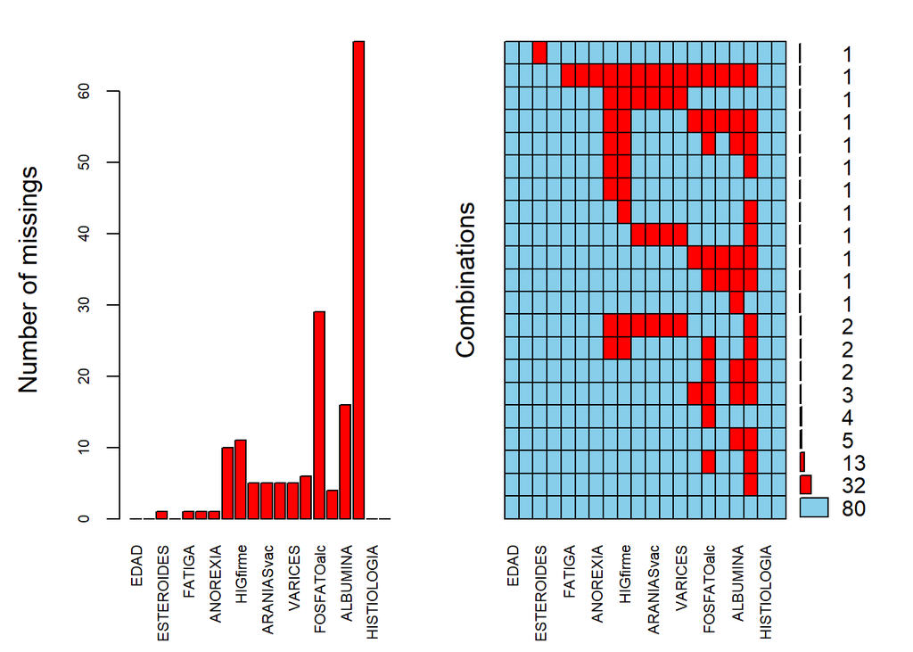

```r
aggr(
  hepatitis,
  numbers = TRUE,
  prop = FALSE,
  cex.axis = 0.7)
```

Otra función que nos permite hacer esto es la función `describe()` del paquete `Hmisc`.

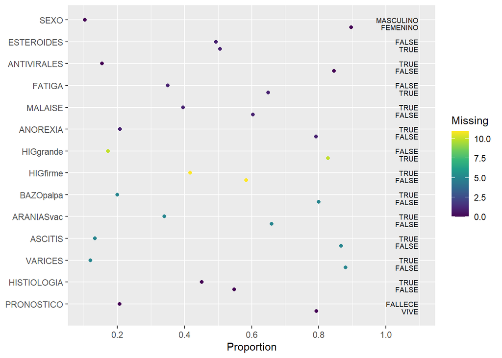

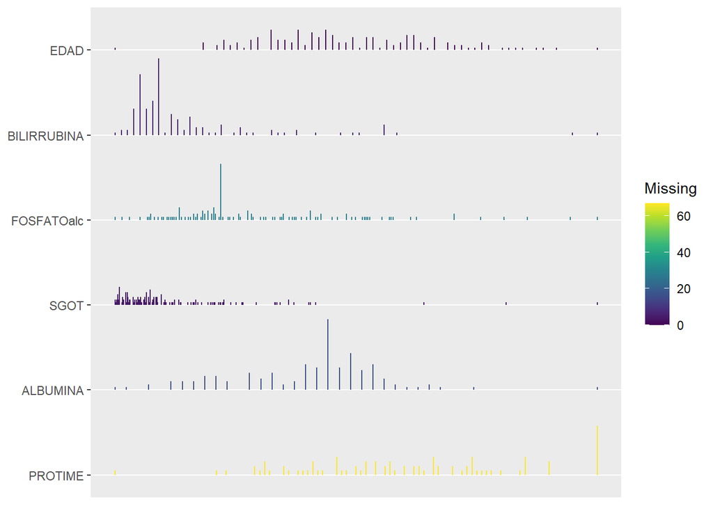

# Imputación de Valores Ausentes

## El paquete `VIM`

Para poder realizar una imputación utilizando el método KNN podemos utilizar la función `kNN()`.

```r
hepatitis.knn <-
  kNN(hepatitis, variable = c("FOSFATOalc", "ALBUMINA"))
aggr(
  hepatitis.knn,
  delimiter = "_imp",
  numbers = TRUE,
  prop = FALSE,
  cex.axis = 0.7
)
```

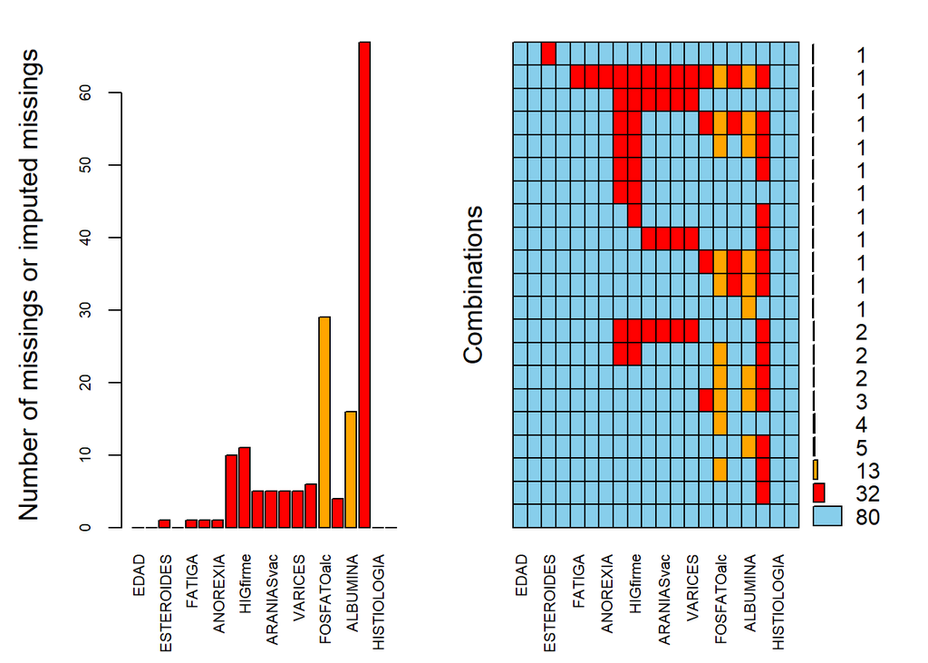

### Ejercicio 6

Una manera de saber qué valores han sido imputados es comprobar los valores de las columnas generedas después de la imputación de los valores que se lleva igual que la variable imputada con el sufijo ’_imp’. Podemos comprobar si los valores de una columna, en este caso usaremos la columna ALBUMINA, han sido imputados imprimiendo el contenido de la columna ALBUMINA_imp. Esto lo hacemos en la siguiente celda de código:

```r
print(hepatitis.knn$ALBUMINA_imp)
```

```
##   [1] FALSE FALSE FALSE FALSE FALSE FALSE  TRUE  TRUE FALSE FALSE FALSE FALSE
##  [13] FALSE FALSE  TRUE FALSE FALSE FALSE FALSE FALSE FALSE FALSE FALSE FALSE
##  [25] FALSE FALSE FALSE FALSE FALSE FALSE FALSE  TRUE FALSE FALSE FALSE FALSE
##  [37] FALSE FALSE FALSE FALSE FALSE FALSE FALSE FALSE  TRUE FALSE FALSE FALSE
##  [49] FALSE FALSE FALSE FALSE FALSE FALSE FALSE  TRUE  TRUE FALSE FALSE  TRUE
##  [61] FALSE FALSE FALSE FALSE FALSE FALSE FALSE FALSE FALSE FALSE FALSE  TRUE
##  [73] FALSE FALSE FALSE FALSE FALSE FALSE FALSE FALSE FALSE FALSE FALSE FALSE
##  [85] FALSE FALSE  TRUE FALSE FALSE FALSE FALSE FALSE FALSE FALSE FALSE FALSE
##  [97] FALSE FALSE FALSE  TRUE FALSE  TRUE FALSE FALSE FALSE FALSE FALSE  TRUE
## [109] FALSE FALSE FALSE FALSE FALSE FALSE FALSE  TRUE FALSE FALSE  TRUE FALSE
## [121] FALSE FALSE  TRUE FALSE FALSE FALSE FALSE FALSE FALSE FALSE FALSE FALSE
## [133] FALSE FALSE FALSE FALSE FALSE FALSE FALSE FALSE FALSE FALSE FALSE FALSE
## [145] FALSE FALSE FALSE FALSE FALSE FALSE FALSE FALSE FALSE FALSE FALSE
```

Como podemos ver esta columna almacena el valor `FALSE` si el valor no fue imputado y el valor `TRUE` si sí que fue imputado.

## El paquete `Hmisc`

### Ejercicio 7

#### Ejercicio 7.1

Imputamos la variable `ALBUMINA` utilizando la media en la siguiente celda de código:

```r
hepatitis.mean <- hepatitis
hepatitis.mean$ALBUMINA <- impute(hepatitis.mean$ALBUMINA, fun=mean)
```

La imprimimos para ver el resultado de esta imputación:

```r
print(hepatitis.mean$ALBUMINA)
```

```
##   [1] 4.000000  3.500000  4.000000  4.000000  4.000000  4.000000  3.817266*
##   [8] 3.817266* 4.400000  3.900000  4.400000  3.700000  3.900000  4.900000
##  [15] 3.817266* 2.900000  4.300000  4.000000  4.100000  4.200000  4.200000
##  [22] 4.100000  4.000000  4.700000  4.300000  3.800000  3.700000  2.700000
##  [29] 3.800000  4.600000  3.800000  3.817266* 5.000000  3.800000  4.300000
##  [36] 4.200000  4.100000  3.900000  4.000000  2.900000  4.000000  4.600000
##  [43] 4.400000  4.400000  3.817266* 4.400000  3.800000  3.300000  4.200000
##  [50] 4.200000  4.000000  4.000000  4.400000  4.000000  4.200000  3.817266*
##  [57] 3.817266* 3.900000  4.300000  3.817266* 4.500000  4.000000  3.400000
##  [64] 3.100000  3.500000  4.200000  3.000000  2.600000  4.000000  3.700000
##  [71] 4.300000  3.817266* 4.400000  4.000000  5.300000  4.100000  3.300000
##  [78] 4.000000  4.400000  4.900000  4.800000  4.200000  4.000000  2.900000
##  [85] 3.900000  4.000000  3.817266* 2.800000  2.800000  4.400000  3.400000
##  [92] 3.300000  4.000000  2.900000  3.600000  4.200000  3.900000  3.500000
##  [99] 4.200000  3.817266* 2.700000  3.817266* 3.000000  3.900000  2.100000
## [106] 6.400000  2.600000  3.817266* 3.600000  3.000000  4.200000  3.800000
## [113] 4.000000  3.000000  3.300000  3.817266* 4.100000  3.900000  3.817266*
## [120] 3.800000  4.000000  2.900000  3.817266* 4.300000  4.000000  4.100000
## [127] 4.000000  2.400000  3.100000  3.300000  4.500000  2.200000  3.800000
## [134] 3.400000  3.800000  4.500000  4.500000  3.500000  2.600000  4.200000
## [141] 2.700000  3.500000  3.000000  3.500000  2.400000  4.200000  3.400000
## [148] 2.800000  4.000000  4.000000  3.300000  4.300000  4.100000  4.100000
## [155] 3.100000
```

#### Ejercicio 7.2

Podemos almacenar en una nueva columna si los valores de la columna ALBUMINA fueron imputados para después utilizar la función `aggr()` de la misma manera que hicimos con anterioridad.

```r
# Almacenamos en una nueva columna si los valores de la columna ALBUMINA
# son imputados
hepatitis.mean$ALBUMINA_imp <- hepatitis$ALBUMINA != hepatitis.mean$ALBUMINA
hepatitis.mean$ALBUMINA_imp[is.na(hepatitis.mean$ALBUMINA_imp)] <- TRUE

aggr(
  hepatitis.mean,
  delimiter = "_imp",
  numbers = TRUE,
  prop = FALSE,
  cex.axis = 0.7
)
```

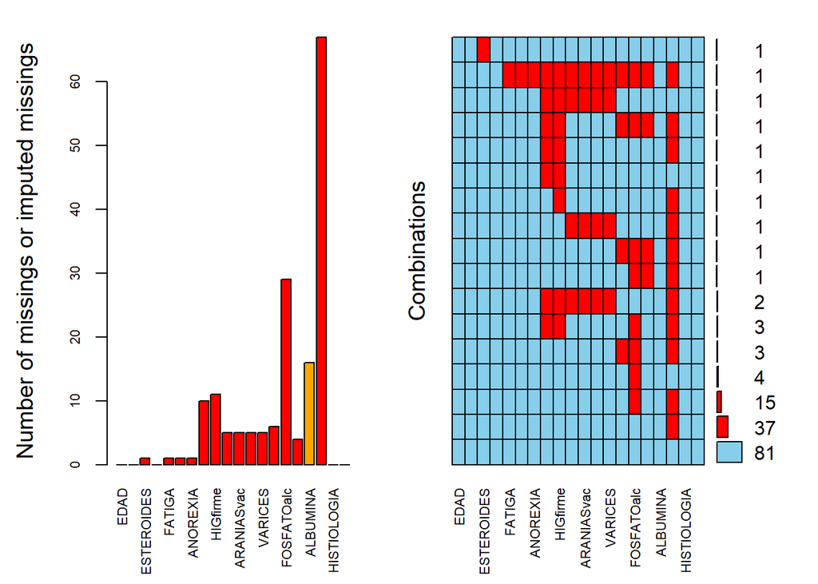

## El paquete `mice`

Ejecutamos el método **Predictive Mean Matching** como prueba:

```r
tempImp.mice <- mice(hepatitis, m=5, method = "pmm", seed = 123)
```

Analizamos el valor de la variable ALBUMINA mediante la siguiente instrucción:

```r
print(tempImp.mice$imp$ALBUMINA)
```

```
##       1   2   3   4   5
## 7   3.8 3.3 2.2 2.7 2.7
## 8   4.4 4.1 4.4 4.0 4.7
## 15  4.4 4.0 4.0 3.9 3.3
## 32  3.1 3.9 3.0 2.7 4.5
## 45  6.4 4.0 4.0 3.3 4.0
## 56  3.5 5.3 4.0 4.0 4.6
## 57  4.1 3.9 3.8 3.7 3.8
## 60  3.9 4.0 3.8 3.8 4.0
## 72  4.0 4.4 2.9 3.8 3.0
## 87  3.4 4.0 3.0 2.2 4.0
## 100 2.7 2.7 3.0 3.9 3.3
## 102 6.4 4.5 4.3 4.2 6.4
## 108 3.0 3.9 3.3 4.4 3.9
## 116 4.0 3.9 4.0 3.3 3.4
## 119 3.6 3.3 2.9 3.4 4.1
## 123 4.0 4.0 4.4 4.4 4.2
```

Imprimimos el método de imputación que se ha utilizado en cada una de las columnas mediante la siguiente instrucción:

```r
print(tempImp.mice$method)
```

```
##        EDAD        SEXO  ESTEROIDES ANTIVIRALES      FATIGA     MALAISE
##          ""          ""       "pmm"          ""       "pmm"       "pmm"
##    ANOREXIA   HIGgrande    HIGfirme   BAZOpalpa  ARANIASvac     ASCITIS
##       "pmm"       "pmm"       "pmm"       "pmm"       "pmm"       "pmm"
##     VARICES BILIRRUBINA  FOSFATOalc        SGOT    ALBUMINA     PROTIME
##       "pmm"       "pmm"       "pmm"       "pmm"       "pmm"       "pmm"
## HISTIOLOGIA  PRONOSTICO
##          ""          ""
```

Hacemos efectiva la imputación en el conjunto de datos original mediante la siguiente instrucción:

```r
hepatitis.imp2 <- complete(tempImp.mice, 1)
```

### Ejercicio 8

#### Ejercicio 8.1

En primer lugar calculamos el porcentage de valores `NA` en cada una de las columnas y lo imprimimos por pantalla:

```r
hepatitis.porcentage.na <- apply(is.na(hepatitis), 2, mean)
hepatitis.porcentage.na <- hepatitis.porcentage.na * 100

print(hepatitis.porcentage.na)
```

```
##        EDAD        SEXO  ESTEROIDES ANTIVIRALES      FATIGA     MALAISE
##   0.0000000   0.0000000   0.6451613   0.0000000   0.6451613   0.6451613
##    ANOREXIA   HIGgrande    HIGfirme   BAZOpalpa  ARANIASvac     ASCITIS
##   0.6451613   6.4516129   7.0967742   3.2258065   3.2258065   3.2258065
##     VARICES BILIRRUBINA  FOSFATOalc        SGOT    ALBUMINA     PROTIME
##   3.2258065   3.8709677  18.7096774   2.5806452  10.3225806  43.2258065
## HISTIOLOGIA  PRONOSTICO
##   0.0000000   0.0000000
```

Ahora usamos las funciones del paquete `VIM` para visualizar la distribución de los valores ausentes:

```r
aggr(
  hepatitis,
  numbers = TRUE,
  prop = FALSE,
  cex.axis = 0.7
)
```

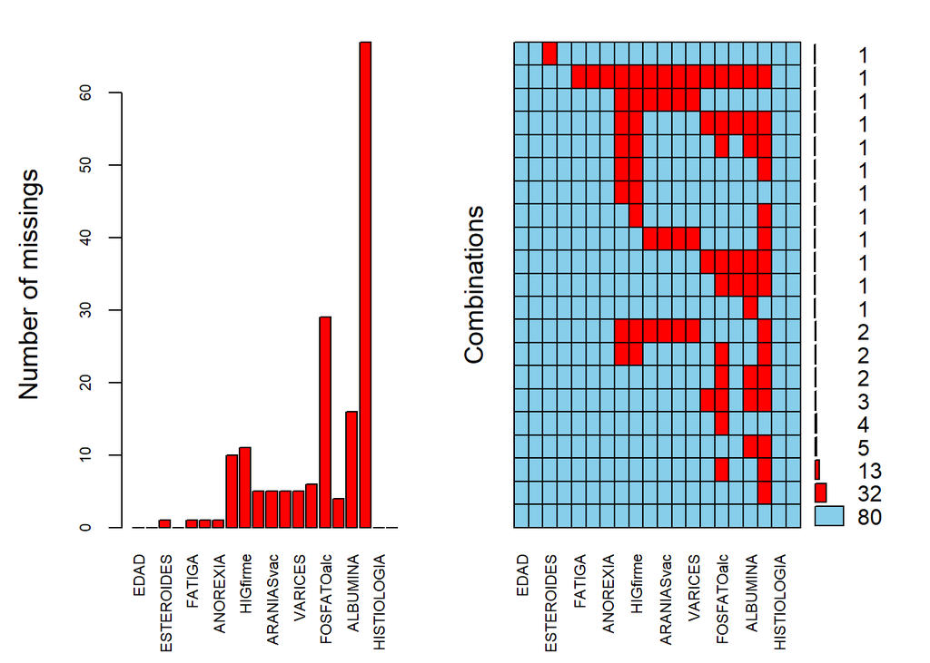

### Ejercicio 8.2

Utilizamos la función `impute()` para imputar los valores ausentes en los atributos SGOT y FOSFATOalc mediante tanto la mediana (`median`) como la media (`mean`). Esto lo hacemos en la siguiente celda de código:

```r
# Utilizando el método `median`
hepatitis.medianImpute <- hepatitis
hepatitis.medianImpute$SGOT <- impute(hepatitis$SGOT, fun = median)
hepatitis.medianImpute$FOSFATOalc <- impute(hepatitis$FOSFATOalc, fun = median)

# Utilizando el método `mean`
hepatitis.meanImpute <- hepatitis
hepatitis.meanImpute$SGOT <- impute(hepatitis$SGOT, fun = mean)
hepatitis.meanImpute$FOSFATOalc <- impute(hepatitis$FOSFATOalc, fun = mean)
```

Analizamos los datos para ver qué cambios apreciamos en el conjunto de datos. Para esto analizamos las distribuciones de las columnas que acabamos de imputar

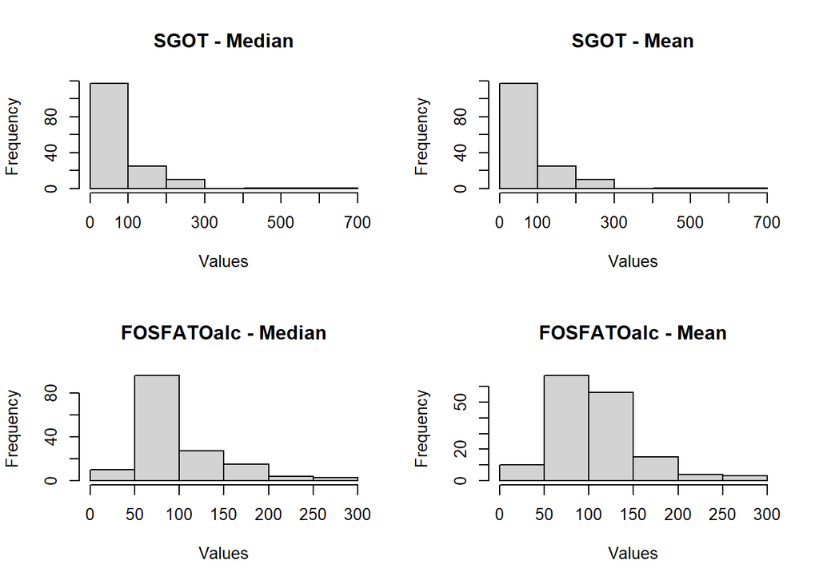

Como se puede observar los valores para la variable SGOT son prácticamente los mismos se haya usado la media como la mediana para calcular los valores a imputar. Esto probablemente se deba a que la media y la mediana se encuentren en el mismo *bin*. Por otra parte no ocurre lo mismo para la variable FOSFATOalc ya que la media y la mediana no se encuentran en el mismo *bin* en este caso.

### Ejercicio 8.3

En primer lugar calculamos las imputaciones tanto con la función `mice()` con el método `pnm` como con la función `kNN`. Esto lo hacemos a continuación:

```r
# Mediante `mice()`
hepatitis.pmmImpute <- mice(hepatitis, m = 5, method = "pmm", seed = 123)
hepatitis.pmmImpute <- complete(hepatitis.pmmImpute, 1)

# Mediante `kNN`
hepatitis.kNNImpute <- kNN(hepatitis, variable = c("SGOT", "FOSFATOalc"))
```

Representamos la distribución de las variables SGOT y FOSFATOalc al igual que antes para comprobar la distribución de los datos al usar estos otros dos métodos de imputación de las variables ausentes:

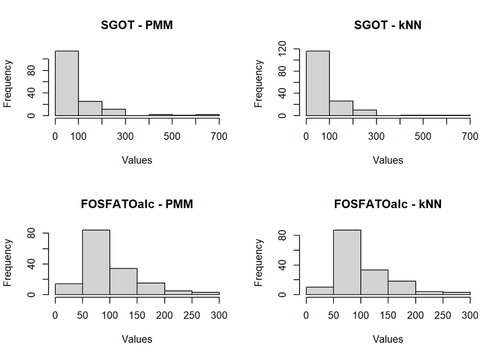

Mediante estas funciones los resultados que se obtienen siguen una distribución muy similar.

### Ejercicio 8.4

Escribimos a cuatro ficheros los datasets generados anteriormente. Como estos ficheros sólo deben contener la información relevante para iniciar las tareas de minería de datos, los almacenamos sin las columnas que acaben en ’_imp’:

```r
# Median
hepatitis.medianImpute$SGOT_imp <- NULL
hepatitis.medianImpute$FOSFATOalc_imp <- NULL
write.csv(
  hepatitis.medianImpute,
  file = './output/hepatitis.medianImpute.csv',
  row.names = FALSE)

# Mean
hepatitis.meanImpute$SGOT_imp <- NULL
hepatitis.meanImpute$FOSFATOalc_imp <- NULL
write.csv(
  hepatitis.meanImpute,
  file = './output/hepatitis.meanImpute.csv',
  row.names = FALSE)

# PMM
hepatitis.pmmImpute$SGOT_imp <- NULL
hepatitis.pmmImpute$FOSFATOalc_imp <- NULL
write.csv(
  hepatitis.pmmImpute,
  file = './output/hepatitis.pmmImpute.csv',
  row.names = FALSE)

# kNN
hepatitis.kNNImpute$SGOT_imp <- NULL
hepatitis.kNNImpute$FOSFATOalc_imp <- NULL
write.csv(
  hepatitis.kNNImpute,
  file = './output/hepatitis.kNNImpute.csv',
  row.names = FALSE)
```

# Clases desbalanceadas

En este apartado lo primero será cargar la librería `ROSE` y la librería `DMwR` que debemos usar.

```r
library(ROSE)
library(DMwR)
```

Probamos el uso de la librería `caret` para hacer un sobremuestreo:

```r
set.seed(123)
hepatitis.upSample <- upSample(
  x = hepatitis[, -ncol(hepatitis)],
  y = hepatitis$PRONOSTICO,
  yname = "PRONOSTICO")
```

Comparamos los resultados para comprobar el efecto de aplicar esta función:

```r
table(hepatitis$PRONOSTICO)
```

```
##
## FALLECE    VIVE
##      32     123
```

```r
table(hepatitis.upSample$PRONOSTICO)
```

```
##
## FALLECE    VIVE
##     123     123
```

Ahora probamos a hacer uso de la función `SMOTE()`:

```r
set.seed(123)
hepatitis.smote <- SMOTE(PRONOSTICO ~ ., data = hepatitis)
```

Y comprobamos el resultado:

```r
table(hepatitis.smote$PRONOSTICO)
```

```
##
## FALLECE    VIVE
##      96     128
```

## Ejercicio 9

### Ejercicio 9.1

Generamos nuevos conjunto de datos con cada una de las técnicas de muestreo vistas anteriormente (`SMOTE()`, `ROSE()`, `downSample()` y `upSample()`) para resolver el problema del desbalanceo de clases:

```r
set.seed(123)

# Submuestreo
hepatitis.downSample <- downSample(
  x = hepatitis[,-ncol(hepatitis)],
  y = hepatitis$PRONOSTICO,
  yname = "PRONOSTICO")

# Sobremuestreo
hepatitis.upSample <- upSample(
  x = hepatitis[, -ncol(hepatitis)],
  y = hepatitis$PRONOSTICO,
  yname = "PRONOSTICO")

# SMOTE
hepatitis.smote <- SMOTE(PRONOSTICO ~ ., data = hepatitis)

hepatitis.rose <- hepatitis
hepatitis.rose[, c(3:13, 19)] = sapply(hepatitis.rose[, c(3:13, 19)], as.numeric)

# ROSE
hepatitis.rose <- ROSE(PRONOSTICO ~ ., data = hepatitis.rose)$data
```

### Ejercicio 9.2

La distribución original es la siguiente:

```r
table(hepatitis$PRONOSTICO)
```

```
##
## FALLECE    VIVE
##      32     123
```

Ahora probaremos a ver la distribución de las clases con cada uno de los métodos de muestreo utilizados anteriormente.

```r
table(hepatitis.downSample$PRONOSTICO)
```

```
##
## FALLECE    VIVE
##      32      32
```

Mediante el método de `downSample()` podemos ver que se escogen de forma aleatoria datos de manera que todas las clases tengan la misma frecuencia que la clase minoritaria, en este caso la clase ‘FALLECE’.

```r
table(hepatitis.upSample$PRONOSTICO)
```

```
##
## FALLECE    VIVE
##     123     123
```

La función `upSample()` realiza un muestreo con reemplazo para igualr las distribuciones de las clases a la clase mayoritaria.

```r
table(hepatitis.smote$PRONOSTICO)
```

```
##
## FALLECE    VIVE
##      96     128
```

```r
table(hepatitis.rose$PRONOSTICO)
```

[output not shown]

Finalmente, la función `ROSE()` usa una técnica basada en bootstrap que ayuda en la tarea de generar ejemplos artificiales cercanos a las muestras de la clase minoritaria.